# 7 Exploratory Data Analysis

Augusto de Souza Cavalcanti

22/04/2021

## 7.1 Introduction

Esse capítulo é sobre análise exploratória de dados, uma maneira de transformar e visualizar os dados de maneira sistemática. AED é um ciclo iterativo.

1- Gerar perguntas/hipóteses sobre os dados.

2- Procurar respostas por meio de visualizações, transformações e modelagem dos dados.

3- Usar o que foi descoberto para refinar as perguntas e gerar novas hipóteses.

O processo não é engessado e com regras claramente definidas, durante a fase inicial você deve investigar todas ideias que vierem a cabeça, algumas serão corretas e outras não. Durante o processo você encontrará áreas produtivas e informações que valem a pena serem passadas e comunicadas.

AED é uma parte importante da análise de dados, até se as perguntas são entregues de bandeja, ainda deve ser feita uma análise sobre a qualidade dos dados. Tratamento de dados é uma das aplicações da análise exploratória.

## 7.2 Questions

O objetivo durante a AED é desenvolver conhecimento sobre seus dados. A maneira mais fácil para isso é fazer perguntas sobre seus dados como ferramentas para guiar sua investigação. Quando uma pergunta é feita, ela foca sua atenção em uma parte específica dos dados e te ajuda a decidir quais visualizações, transformações e modelos devem ser feitos.

AED é um processo criativo, dessa maneira a chave para gerar boas perguntas é gerar muitas perguntas. Inicialmente é difícil gerar boas perguntas pois não sabemos os insights estão no dataset. Por outro lado a cada pergunta vai gerar uma exposição a uma nova faceta dos seus dados e permitir e aumentar sua chance de fazer descobertas e novas perguntas. Voce pode rapidamente chegar as partes mais interessantes dos seus dados e criar perguntas efetivas, se a cada pergunta feita voce gere uma nova pergunta baseada nos seus achados.

Não existe uma regra para quais perguntas devem ser feitas, mas existem dois tipos de pergunta que são úteis para fazer descobertas nos seus dados:

1- Qual tipo de variação ocorre entre minhas variáveis?

2- Qual tipo de covariação ocorre entre minhas variáveis?

O resto do capítulo será focado nessas perguntas, mas precisamos definir alguns termos para facilitar:

- Uma variável é uma quantidade, qualidade ou propriedade que pode ser medida.
- Um valor é o estado de uma variável quando você mede. Essa valor pode mudar de medição para medição.
- Uma observação é um conjunto de medidas feitas sob uma condição parecida. Normalmente todas medidas de uma observação são feitas ao mesmo tempo no mesmo objeto. Uma observação contém varios valores, cada um associado à uma variável. Podemos nos referir a observações como data points.
- Tabular Data é uma série de valores, cada um associado com uma variável e uma observação. Tabular data é Tidy se cada valor é colocado em uma célula, cada variável em uma coluna e cada observação em uma linha.

Todos dados que trabalhamos até agora eram tidy, a maioria dos dados na vida real não vira dessa forma e devem ser trabalhados.

## 7.3 Variation

Variação é a tendência de valores de uma variável de mudarem de medição em medição. É facíl observar variação na vida real, qualquer variável contínua medida duas vezes assume valores diferentes. Até se medirmos a velocidade da luz 2 vezes teremos erros pequenos em cada uma das medições. Variáveis categóricas também podem ser diferentes se medidas em assuntos diferentes ou tempos diferentes. Cada variável tem seu padrão de variação, que pode revelar informações interessantes. A melhor maneira de entender esse padrão é visualizar a distribuição dos valores da variável.

### 7.3.1 Visualising Distributions

A maneira de vizualizar a distribuição depende se essa variável é categórica ou contínua. Uma variável é categórica se só puder receber um pequeno conjunto de valores. No r essas variáveis são salvas como factors ou character vectors. Para vizualizar a distribuição podemos usar um gráfico de barras.

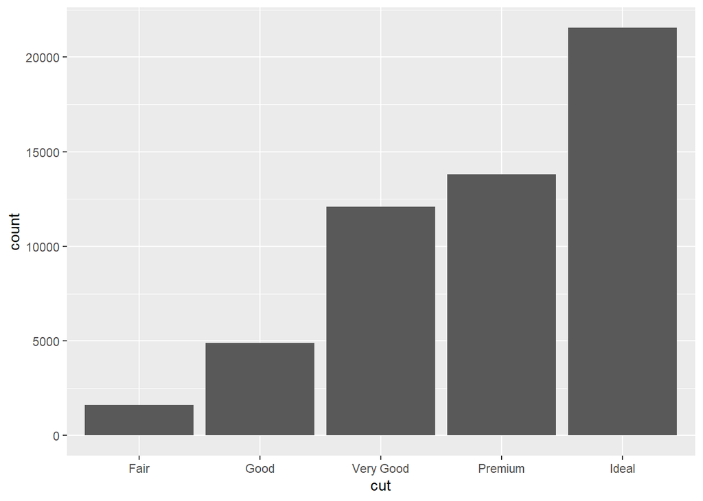

```r
ggplot(diamonds) + geom_bar(aes(x=cut))
```

Uma variável é contínua se pode receber qualquer valor de um infinito conjunto de valores. Datas e Números são exemplos de variáveis contínuas. Para analisar a distribuição de uma variável contínua usaremos um histograma.

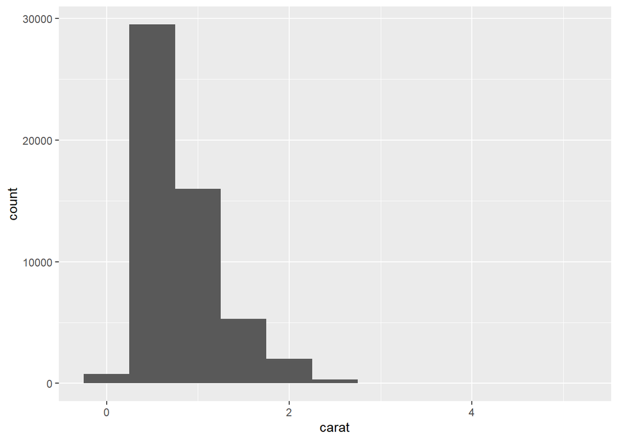

```r
diamonds %>% ggplot() + geom_histogram(aes(x=carat),binwidth = 0.5)
```

O cálculo pode ser feito a mão usando count e cut_width.

```r
diamonds %>% count(cut_width(carat,0.5))
```

```
## # A tibble: 11 x 2
##    `cut_width(carat, 0.5)`     n
##    <fct>                   <int>
##  1 [-0.25,0.25]              785
##  2 (0.25,0.75]             29498
##  3 (0.75,1.25]             15977
##  4 (1.25,1.75]              5313
##  5 (1.75,2.25]              2002
##  6 (2.25,2.75]               322
##  7 (2.75,3.25]                32
##  8 (3.25,3.75]                 5
##  9 (3.75,4.25]                 4
## 10 (4.25,4.75]                 1
## 11 (4.75,5.25]                 1
```

Podemos sempre testar outros tamanhos para os intervalos. Por exemplo, podemos olhar os mesmos dados anteriores porem com uma espessura do intervalo de 0.1 e considerando apenas diamantes com menos de 3 quilates.

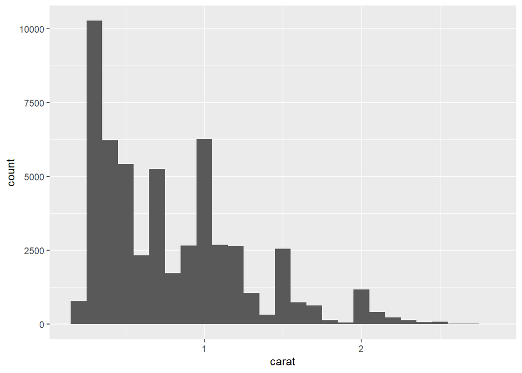

```r
diamonds %>% filter(carat <3) %>% ggplot() + geom_histogram(aes(carat),binwidth = 0.1)
```

Se o desejo é ter vários histogramas no mesmo gráfico, é melhor usar a função geom_freqpoly(), que faz as mesmas coisas porém usando linhas e não barras.

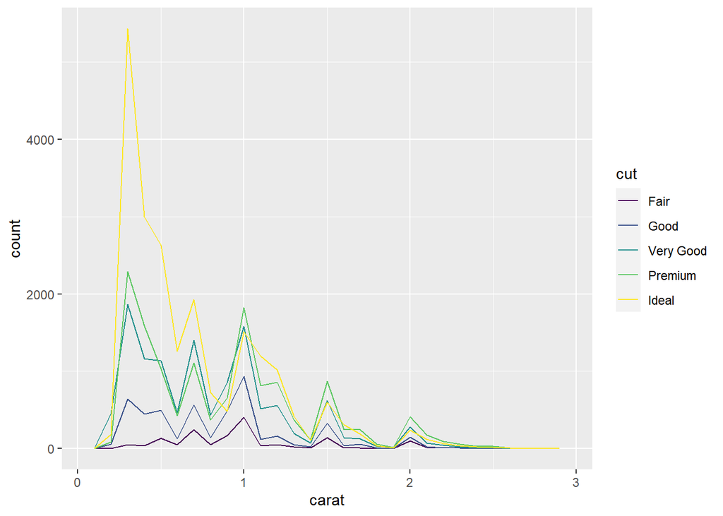

```r
diamonds %>% filter(carat<3) %>% ggplot() + geom_freqpoly(aes(carat,color=cut),binwidth=0.1)
```

Agora que temos a capacidade de visualizar a variação, que tipo de perguntas devem ser feitas? Abaixo teremos uma lista de perguntas a serem feitas a seguir, porém é sempre bom se perguntar sobre o que se deseja saber mais sobre o gráfico e o que pode ser enganoso e levar a uma conclusão errada.

### 7.3.2 Typical Values

Para transformar os dados do histograma e gráfico de barras em perguntas úteis procure por coisas inesperadas:

- Quais valores são os mais comuns? Por quê?
- Quais valores são raros? Por quê?
- Você consegue indentificar algum padrão inesperado? Algo consegue explicar esse padrão?

A seguir algumas perguntas que p histograma a seguir pode gerar.

- Por que existem mais diamantes com quilates inteiros e frações comuns?
- Por que existem mais diamantes um pouco a direita dos picos do que a esquerda?
- Por que não existem diamantes maiores que 3 quilates.

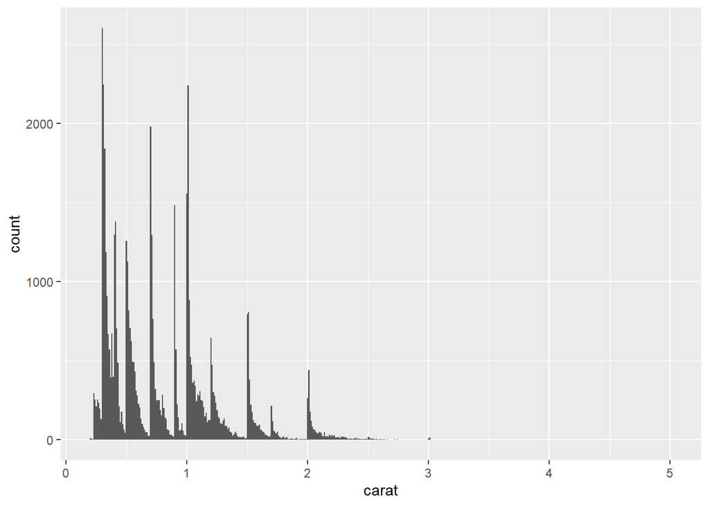

```r
diamonds %>% ggplot() + geom_histogram(aes(x=carat),binwidth = 0.01)
```

Clusters de valores similares indicam que existem subgrupos nos dados, para entender os subgrupos pergunte:

- Como as observações em cada cluster são similares entre si?
- Como as observações em cada cluster são em cada cluster diferentes entre eles?
- Como os clusters podem ser explicados?
- Por que as aparências dos clusters podem ser enganosas?

O histograma a seguir apresenta mostra a duração de 272 erupções em um vulcão nos Estados Unidos. Podemos perceber clusters em dois grupos: erupções curtas (+- 2 min) e erupções longas entre 4 e 5 minutos.

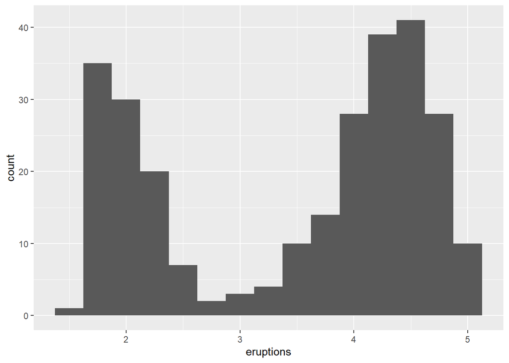

```r
ggplot(data = faithful, mapping = aes(x = eruptions)) +
  geom_histogram(binwidth = 0.25)
```

Muitas das perguntas acima vão levar a exploração de relações entre variáveis. Para por exemplo ver se os valores de uma variável pode explicar a outra.

### 7.3.3 Unusual Values

Outliers são valores que não se encaixam em um padrão do seus dados. Quando temos muitos dados, outliers se tornam difíceis de serem visualizados nos seus dados, EX:

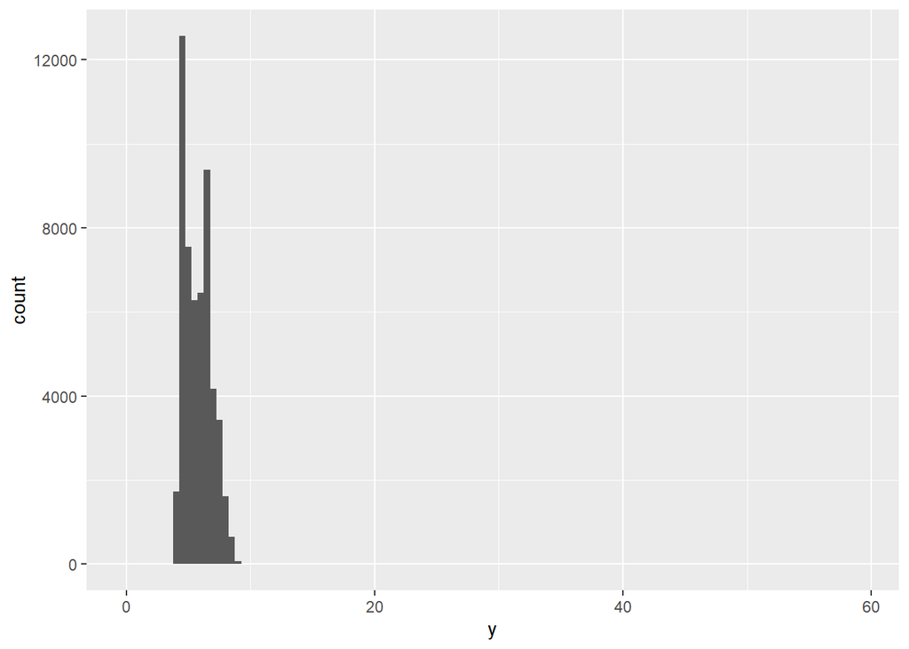

```r
ggplot(diamonds) + geom_histogram(aes(x=y),binwidth = 0.5)
```

A única evidência de outliers que temos são os eixos y extremamente longos apesar de não podermos ver nada, um zoom na área inferior pode nos ajudar.

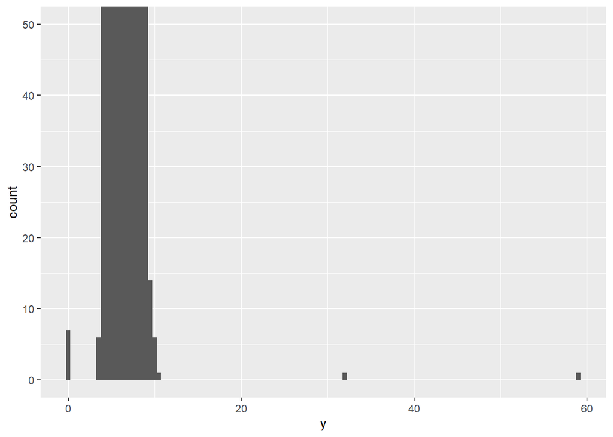

```r
ggplot(diamonds) + geom_histogram(aes(x=y),binwidth = 0.5) + coord_cartesian(ylim=c(0,50))
```

Agora podemos perceber que existem dados individuais em algumas partes que não tinhamos visto antes e um pequeno conjunto no 0. Existem dados no 0 e maiores que 30 que não tinhamos percebido antes. Podemos usar o dplyr para selecionar esses valores.

```r
diamonds %>% filter(y>20 | y <3) %>% select(price,y,x,z) %>% arrange(y)
```

```
## # A tibble: 9 x 4
##   price     y     x     z
##   <int> <dbl> <dbl> <dbl>
## 1  5139   0    0     0
## 2  6381   0    0     0
## 3 12800   0    0     0
## 4 15686   0    0     0
## 5 18034   0    0     0
## 6  2130   0    0     0
## 7  2130   0    0     0
## 8  2075  31.8  5.15  5.12
## 9 12210  58.9  8.09  8.06
```

Podemos perceber que todos esses dados são provavelmente erros nas entradas de dados. Os dados x,y,z mostram as dimensões dos diamantes, diamantes com dimensão 0 não existem, e os diamantes com dimensão y extremamente alta são muito baratos em relação ao preço que assumiriam se tivessem esse valor de y.

É interessante repetir suas análises com e sem outliers, caso eles tenham um efeito pequeno nos dados e voce não consegue explicar o motivo deles estarem lá é razoável substituilos por NA e seguir. No entanto se eles tiverem grandes efeitos na sua análise voce não deve removelos sem saber explicar o motivo (Erro na entrada de dados, nesse caso remover), o correto é achar o motivo e explicar porque foram removidos.

### Exercícios 7.3.4

1. Explore a distribuição de x,y,z. O que voce descobriu, conclua sobre qual é a altura, qual a largura e a profundidade se tivessemos que advinhar.

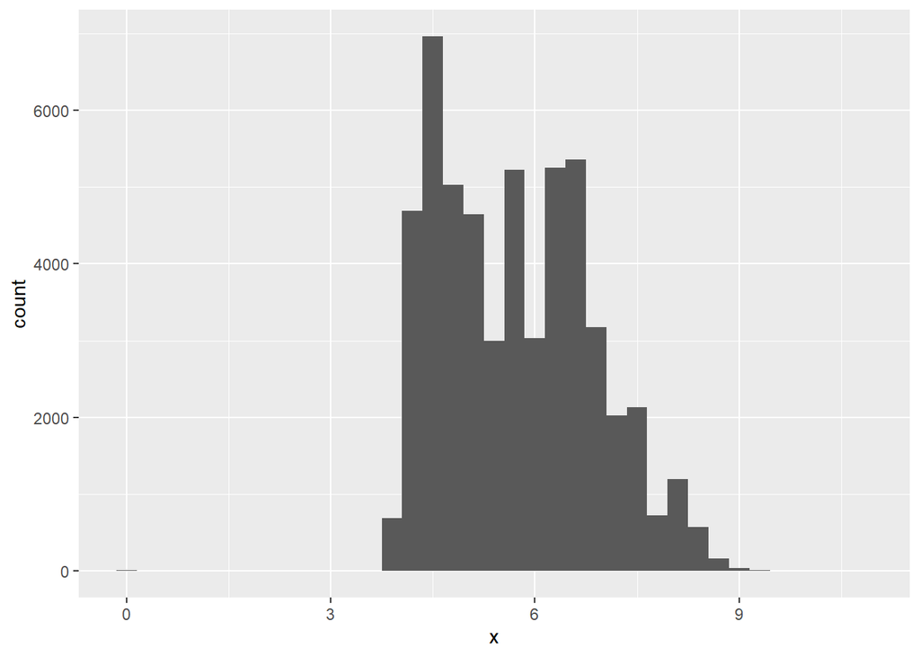

```r
ggplot(diamonds) + geom_histogram(aes(x = x),binwidth = 0.3)
```

A distribuição de x não parece ter outliers grandes de entrada de dados muito da mesma maneira que y pois seus eixos são do tamanho esperado. Os outliers em 0 no entanto continuam existindo. A maioria dos dados se concentra entre 4 e 8 mm.

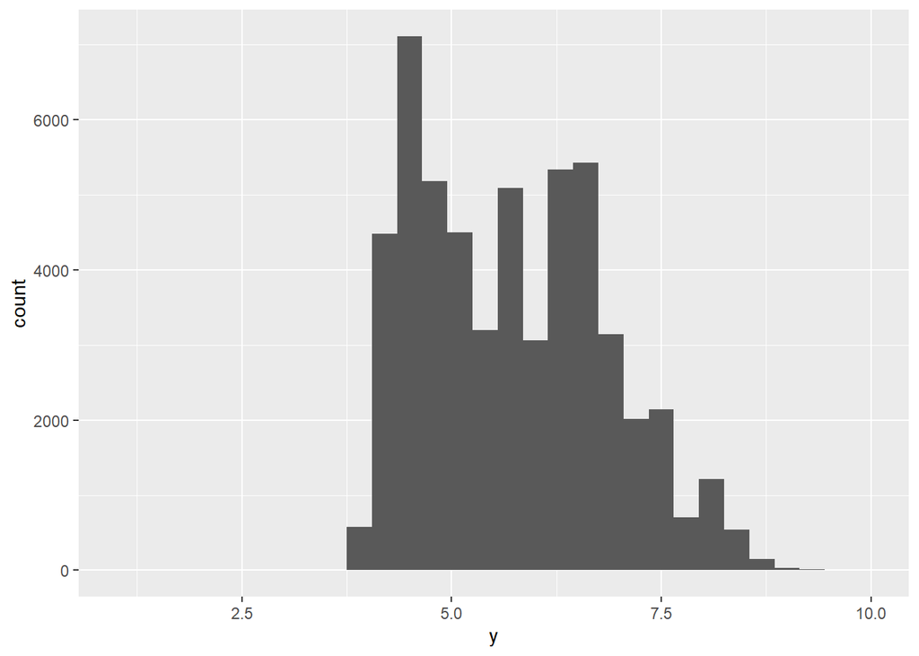

```r
ggplot(diamonds) + geom_histogram(aes(x = y),binwidth = 0.3) + coord_cartesian(xlim=c(1,10))
```

A distribuição de y, como concluido previamente tem alguns outlieres vindos de entrada de dados, porém desconsiderando eles seguem o mesmo de x com a maioria dos dados concentrados entre 4 e 8 mm.

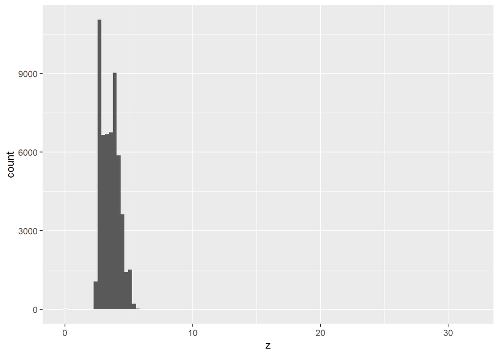

```r
ggplot(diamonds) + geom_histogram(aes(x = z),binwidth = 0.3)
```

Pelo gráfico, existem outliers a direita devido a extensão do eixo x, podemos verificar os valores que se encontram e fazer uma tabela para conferir se esses são vindos de entrada de dados.

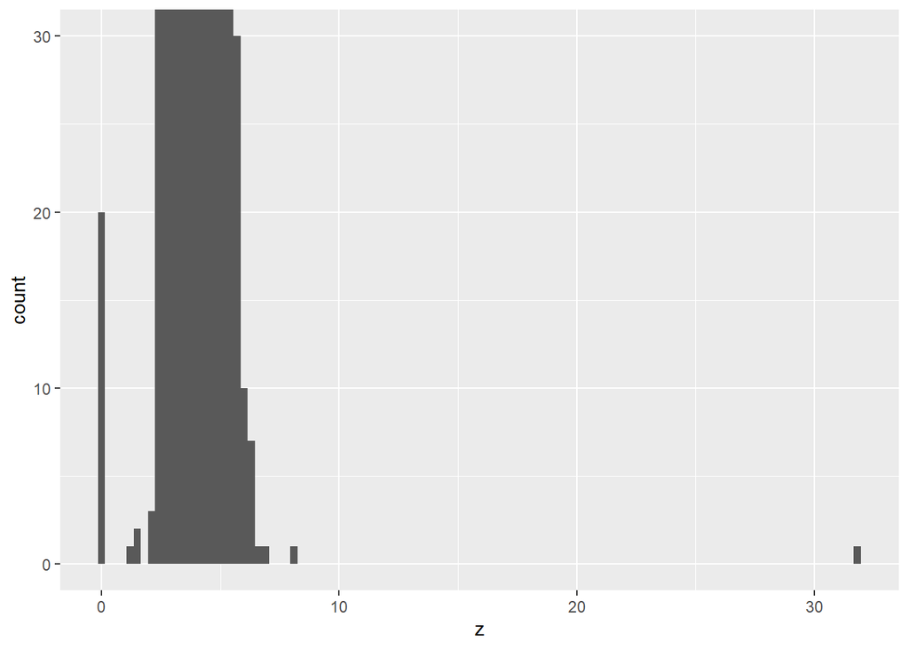

```r
ggplot(diamonds) + geom_histogram(aes(x = z),binwidth = 0.3) + coord_cartesian(ylim=c(0,30))
```

```r
diamonds %>% filter(z<2 | z> 8) %>% select(price,z,y,x) %>% arrange(z)
```

```
## # A tibble: 25 x 4
##    price     z     y     x
##    <int> <dbl> <dbl> <dbl>
##  1  3142     0  6.48  6.55
##  2  3167     0  6.6   6.66
##  3  3696     0  6.47  6.5
##  4  3837     0  6.47  6.5
##  5  4731     0  7.04  7.15
##  6  4954     0  6.62  0
##  7  5139     0  0     0
##  8  5564     0  6.83  6.88
##  9  6381     0  0     0
## 10 12631     0  8.45  8.49
## # ... with 15 more rows
```

Os diamantes com z = 0 podem ser considerados erros na entrada de dados, já os diamantes com z entre 1 e 2 podem não devem ser descartados pois não temos indicação que esses são erros de entrada. Os diamantes maiores que 8 podem ser descartados, o preço deles não condiz com o que seria esperado caso suas dimensões (x,y e z) realmente fossem as que foram apresentadas.

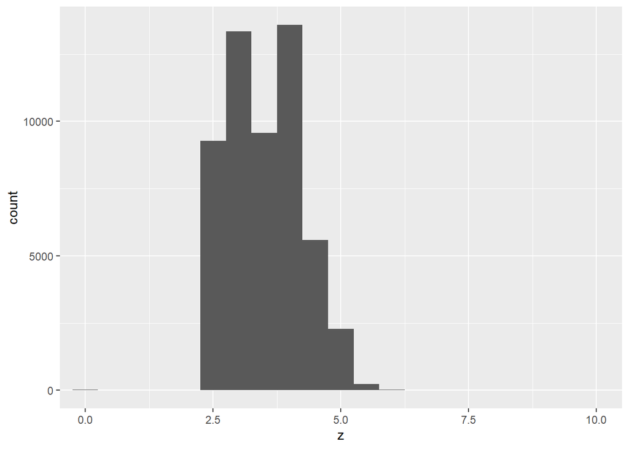

```r
diamonds %>% ggplot(aes(x=z)) + geom_histogram(binwidth = 0.5) + coord_cartesian(xlim = c(0,10))
```

A maioria dos diamantes parece ter seu Z entre 2.5 e 5, diferente das outras duas dimensões.

Acredito devido a essa distribuição e ao conhecimento básico sobre diamantes:

- Z: Profundiade = Altura R: Profundidade
- x / Y : Largura e Comprimento não sei qual é qual. R: X= Comprimento , Y= Largura
2. Explore a distribuição de preços. Explore diferentes tamanhos de intervalo:

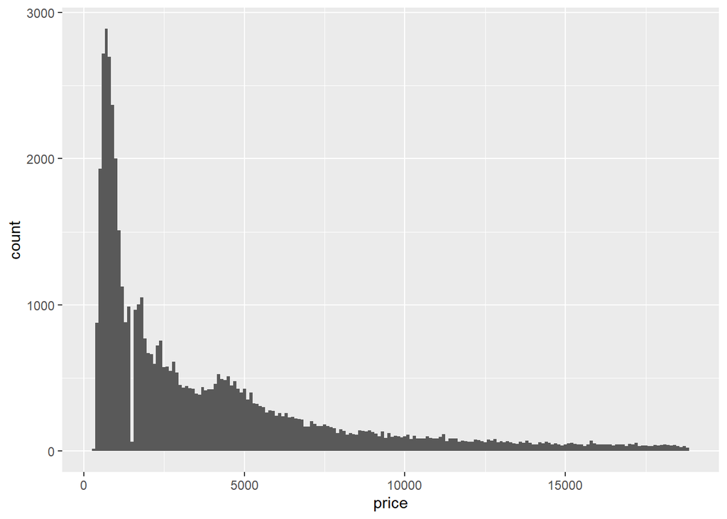

```r
diamonds %>% ggplot + geom_histogram(aes(x=price),binwidth = 100)
```

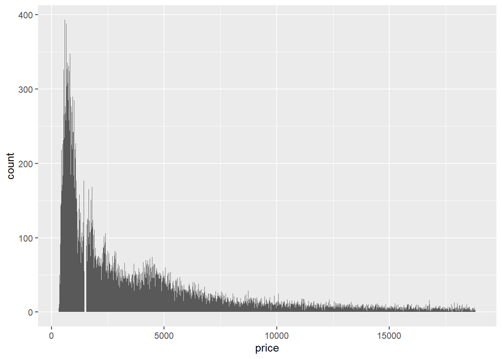

```r
diamonds %>% ggplot + geom_histogram(aes(x=price),binwidth = 10)
```

Com esses valores vemos grandes picos na distribuição, isso acontece possivelmente por um arredondamento de preços para final 99 por exemplo. Podemos testar:

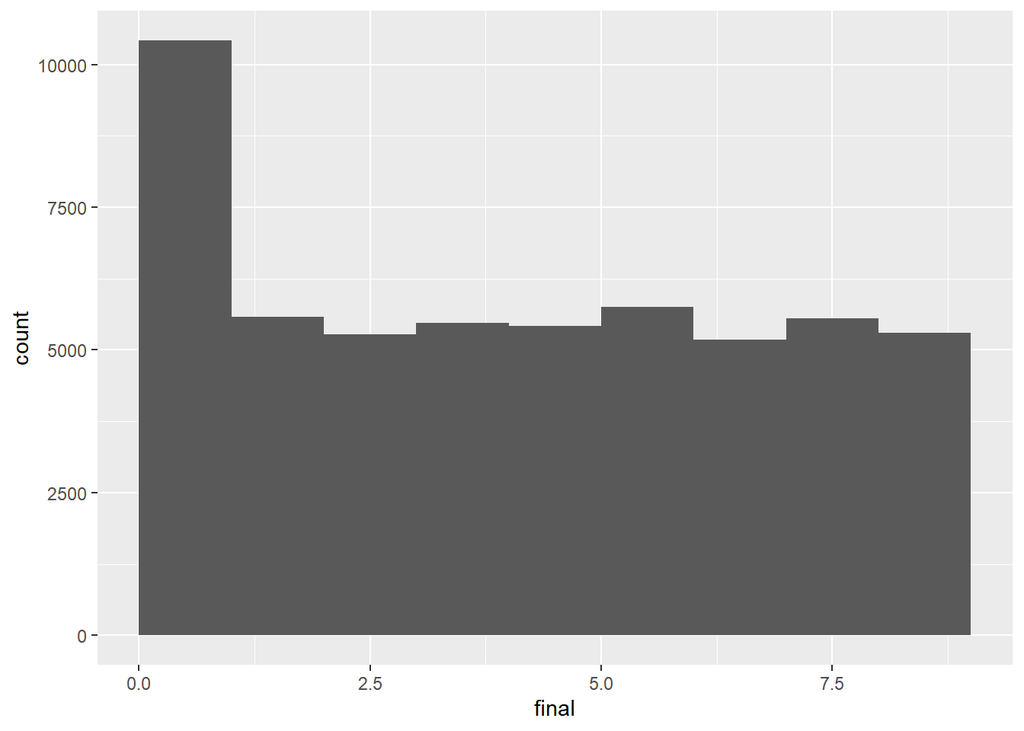

```r
diamonds %>% mutate(final = price %% 10) %>% ggplot() + geom_histogram(aes(x=final),binwidth = 1,center=0.5)
```

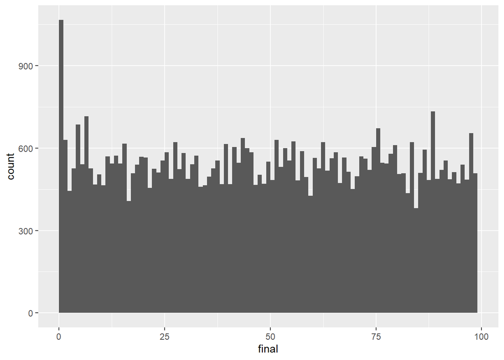

```r
diamonds %>% mutate(final = price %% 100) %>% ggplot() + geom_histogram(aes(x=final),binwidth = 1,center=0.5)
```

Podemos ver que os finais não são normalmente distribuidos e que tendem a ter prefêrencias sobre os ultimos digitos. O mais comum são escolhas terminadas em 0.

3. Quantos diamantes tem 1 carat, quantos tem 0.99? Por que?

```r
diamonds %>% filter(carat %in% c(0.99,1)) %>% count(carat)
```

```
## # A tibble: 2 x 2
##   carat     n
##   <dbl> <int>
## 1  0.99    23
## 2  1     1558
```

Podemos ver que muitos diamantes tem 1 quilate e pouquissimos tem 0.99. Diamantes não são formados com uma probabilidade maior de ter um que o outro, então essa diferença não pode ser natural. O motivo da diferença provavelmente é o arredondamento.

4. Compare coord_cartesian() com xlim e ylim.

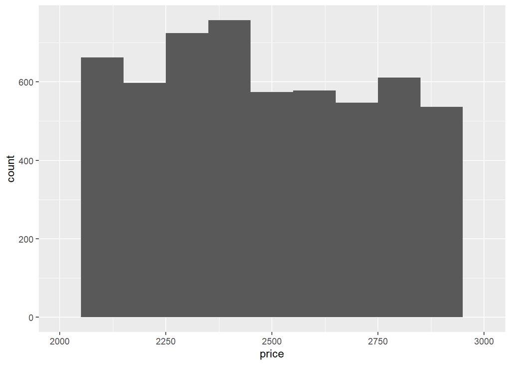

```r
diamonds %>% ggplot(aes(price)) + geom_histogram(binwidth = 100) + xlim(c(2000,3000))
```

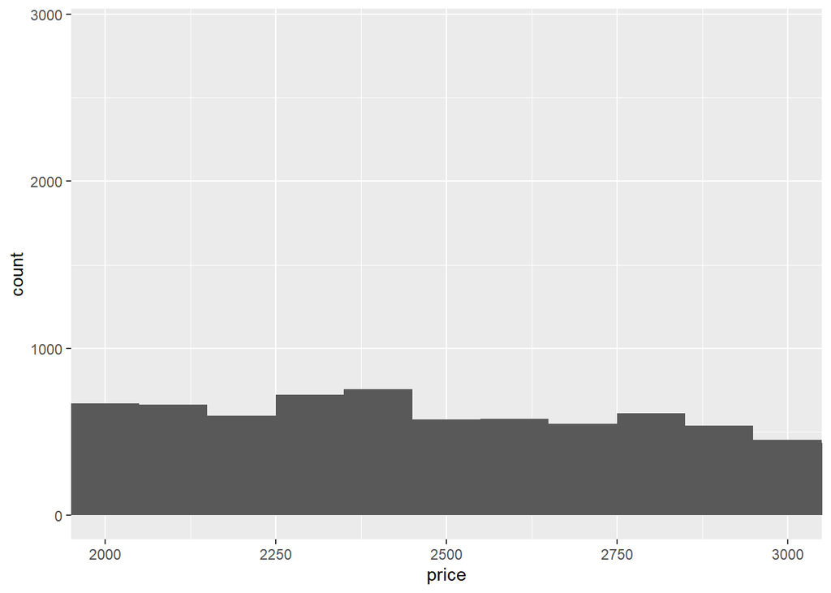

```r
diamonds %>% ggplot(aes(price)) + geom_histogram(binwidth = 100) + coord_cartesian(xlim=c(2000,3000))
```

A diferença é que o coord cartesian não remove os dados e cria o histograma depois, ele apenas da zoom e mantem a altura relativa a outras barras que existem, o xlim cria o histograma considerando apenas os dados naquele intervalo existentes, dessa maneira os eixos são reajustados

## 7.4 Missing Values

Quando valores não usuais são enconctrados, temos duas opções se quisermos continuar para a análise:

- Podemos remover todas as linhas que tem contem esses valores:

```r
diamonds %>% filter(between(y,3,20))
```

```
## # A tibble: 53,931 x 10
##    carat cut       color clarity depth table price     x     y     z
##    <dbl> <ord>     <ord> <ord>   <dbl> <dbl> <int> <dbl> <dbl> <dbl>
##  1  0.23 Ideal     E     SI2      61.5    55   326  3.95  3.98  2.43
##  2  0.21 Premium   E     SI1      59.8    61   326  3.89  3.84  2.31
##  3  0.23 Good      E     VS1      56.9    65   327  4.05  4.07  2.31
##  4  0.29 Premium   I     VS2      62.4    58   334  4.2   4.23  2.63
##  5  0.31 Good      J     SI2      63.3    58   335  4.34  4.35  2.75
##  6  0.24 Very Good J     VVS2     62.8    57   336  3.94  3.96  2.48
##  7  0.24 Very Good I     VVS1     62.3    57   336  3.95  3.98  2.47
##  8  0.26 Very Good H     SI1      61.9    55   337  4.07  4.11  2.53
##  9  0.22 Fair      E     VS2      65.1    61   337  3.87  3.78  2.49
## 10  0.23 Very Good H     VS1      59.4    61   338  4     4.05  2.39
## # ... with 53,921 more rows
```

Não é o ideal se temos um valor errado para uma observação não significa que todos valores serão. Além disso quando temos dados de baixa de qualidade podemos retirar uma porção consideravel dos dados.

- Substituir os valores não usuais por NA, fazemos isso usando mutate e criando uma cópia da variável modificada. Usando a função ifelse o processo se torna bem simples.

```r
diamonds2 <- diamonds %>% mutate(y = ifelse(y<3 |y>20,NA,y))
```

Quando plottamos algo com ggplot os valores NA não são colocados porém um aviso é feito sobre isso. Para que o aviso não apareça temos que usar na.rm=T.

```
## Warning: Removed 9 rows containing missing values (geom_point).
```

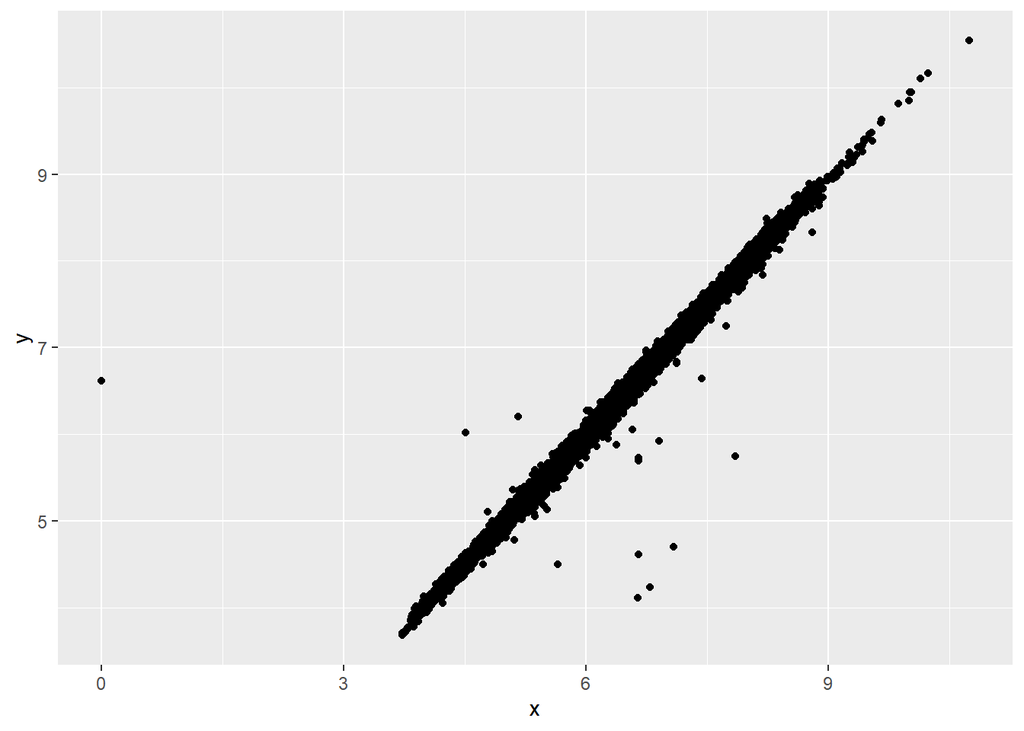

```r
ggplot(diamonds2) + geom_point(aes(x=x,y=y))
```

Outras vezes queremos saber o que valores faltantes significam, no df flights usado anteriormente, os voos com dep_time NA significavam que o voo foi cancelado. Então poderiamos fazer uma análise do horário previsto de voos cancelados .

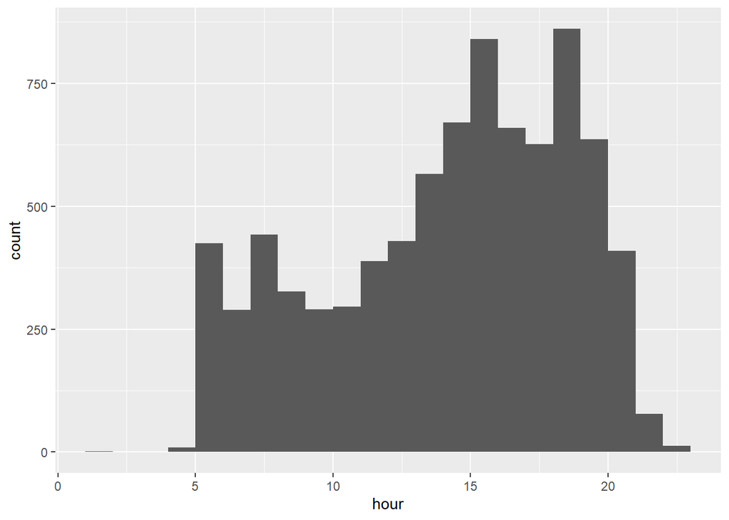

```r
flights %>% filter(is.na(dep_time)) %>% ggplot() + geom_histogram(aes(x=hour),binwidth = 1,center=0.5)
```

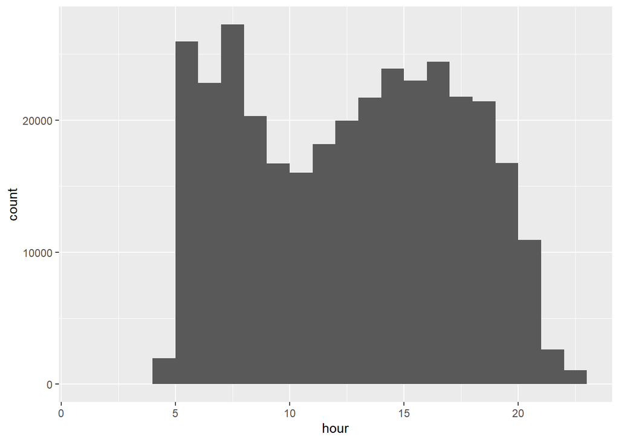

```r
flights %>% ggplot() + geom_histogram(aes(x=hour),binwidth = 1,center=0.5)
```

Com os dois gráficos em conjunto podemos concluir que mais voos são cancelados em horários mais tardios, podiamos ainda fazer esse histograma para as proporções de voos cancelados.

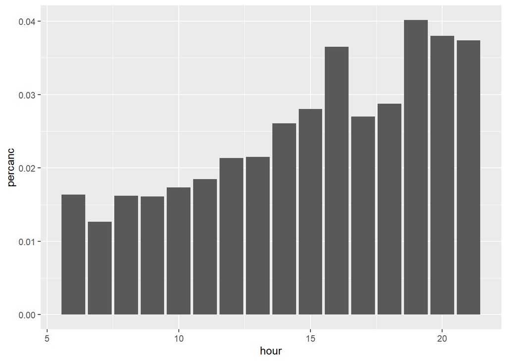

```r
flights %>% mutate(cancelado = is.na(dep_time)) %>% group_by(hour) %>% summarise(total= n(),cancelados = sum(cancelado)) %>% filter(total>3000) %>% transmute(hour,percanc = cancelados/total) %>% ggplot() + geom_col(aes(hour,percanc))
```

### Exercícios 7.4.1

1. O que acontece com dados faltantes em um histograma? O que acontece com dados faltantes em gráfico de barras? Qual a diferença?

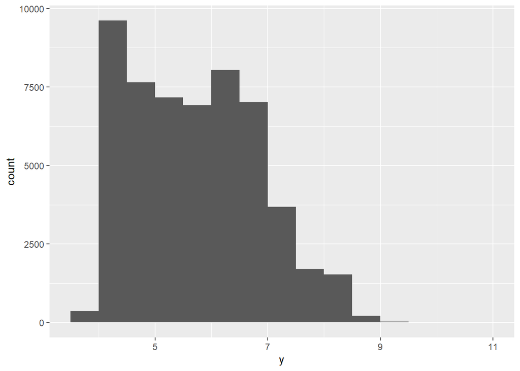

```r
diamonds2 %>% ggplot(aes(y)) + geom_histogram(binwidth = 0.5,center=0.25)
```

No histograma valores NA são removidos.

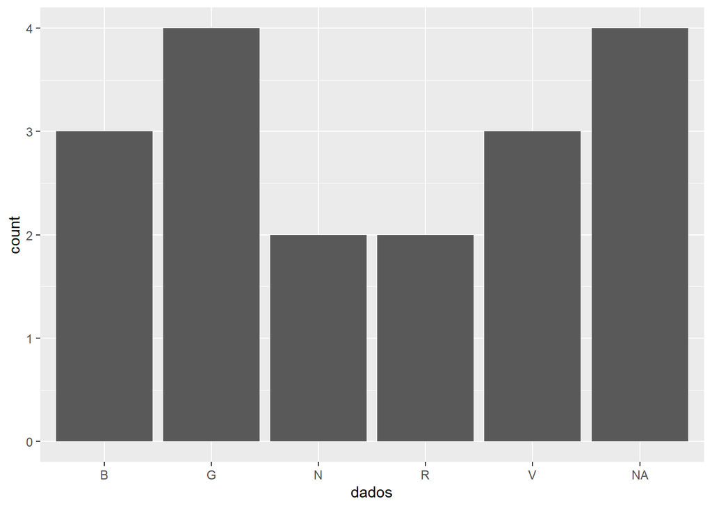

```r
dados <- tibble(dados= c('G','G','G','G','B','B','B','V','V','V','N','N','R','R',NA,NA,NA,NA))

dados %>% ggplot() + geom_bar(aes(dados))
```

No gráfico de barras por se tratar de valores categoricos é feita uma barra com valores faltantes. Como no histograma não teria uma posição correta para a barra isso não acontece.

2. O que na.rm faz em mean e sum?

na.rm remove os valores faltantes dos dados antes de fazer as contas.